# Opinion: UC Strike Action Vote

Liza Wood

October 26, 2022

UC students are voting on whether they want to strike this week. The strike is driven by many years running of incremental bargaining for improved cost of living and rights for all types of student-related UC employment, from junior specialists and GSRs, to TAs and post-docs. The main point of the strike that interests me is the [proposed cost of living adjustments](https://www.fairucnow.org/cola/). I can attest to the general sentiment that graduate students feel over-worked, underpaid, and constantly battling administrative and bureaucratic hurdles to ensure their employment every 12 weeks. But at the same time, the UC bargaining team has proposed a pretty radical number for fair wages for all ‘Grad Workers’ (GSRs and TAs): $54,000 as a minimum salary, assuming that graduate students are working 50% year-round.

The Union’s proposal of $54,000 for 50% sounds high, and it is. But my first questions are about trying to understand how high this really is, relative to current student salaries, and how this compares to other graduate student salaries.

Note: This dive into cost of living is based primarily on on UC Davis data, and no other UC campus. I recognize that Davis is among the UC campuses with the lowest cost of living and so these analyses do not speak to all of the campuses.

Want to dig into these numbrs yourself? All data and analyses can be found here: https://github.com/liza-wood/uc-strikevote

## How much money do UC Davis graduate students make?

The UAW website says that the ‘most common’ salary is $23,247, citing UCDP. I assume this is [UC Data Portal](https://data.ucop.edu/), but it is not clear how to access this, when the data is from, and how that was calculated. So instead I took data from the [UCD Grad Studies Pay Scale document](https://ucdavis.app.box.com/v/salaryscale2122) that comes out annually (this one is old because, well, still bargaining). Here we have a flat TA rate of $46,493, which is a 9-month rate at 100%, calculating out to $2,582.95 each month TAing at 50%. There are also GSR rates, which has default steps for a compensation plan, whereby Step III is the initial appointment – so I will consider this a GSR minimum. The Step III GSR rate is $52,604 at a 12-month rate, calculating out to $2,191.84 each month GSRing at 50%.

## How does UC Davis pay compare to other graduate programs?

It is important to know your worth on the market. Graduate students generally know that pay is low, but how low is too low? What is a competitive asking price? One way to answer this question is compare UC Davis to other graduate pay rates across the country.

I selected a handful of other universities that feel comparable to UC Davis, and that have some overlap with my work in environmental policy. They feel comparable in that they are large public universities from various locations across the country, capturing a range of living costs. And ss a member of the Environmental Science and Policy Department, I wanted to know how graduate students are paid in schools that have comparable Environmental Science/Environmental Policy programs. I settled on the following universities, with their details below:

| University | Undergrad # | Postgrad # |
| --- | --- | --- |
| University of California, Davis | 31,162 | 8,869 |
| University of Washington | 32,779 | 16,246 |
| University of Florida | 37,874 | 15,916 |
| University of Michigan | 31,329 | 16,578 |
| University of Georgia | 40,118 | 9,952 |
| University of Indiana | 34,253 | 11,075 |
| Arizona State University | 38,528 | 10,943 |

I grabbed reported pay rates for graduate students from each of these schools. The details of where I found and collated these data can be found annotated in my [grad-pay-rate script](https://github.com/liza-wood/uc-strikevote/blob/main/code/grad-student-pay.R). Good news is: other school policies appear much less confusing than UCD’s. They tend to set a clear minimum and may only have a few employment categories with different pay grades. But because the minimum was most often reported, I’ll still with using the *minimum*/floor pay for these graduate programs when comparing pay scales.

Let’s first see how UCD grad student pay measures up in absolute terms.

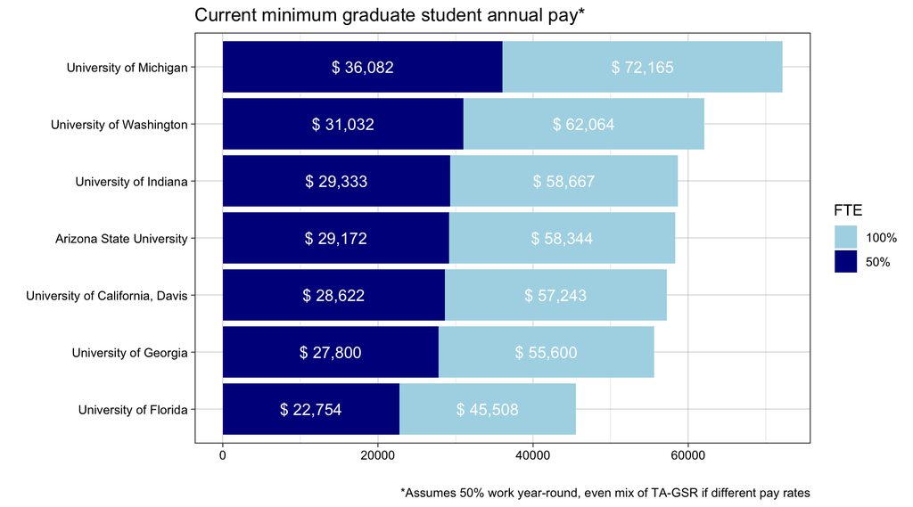

## How does UCD pay compare to other program given the cost of living in each city?

How to measure cost of living in a city is not easy. UAW seems to be relying on union member surveys to gather data on how much rent costs are for graduate students, which they use as the basis to discuss rent burden. But luckily, there is a tool for a well-documented understanding of living wages provided through the [MIT’s Living Wage Calculator](https://livingwage.mit.edu/).

| University | City | MIT Living Wage |
| --- | --- | --- |
| University of Michigan | Ann Arbor, MI | $ 38,537 |
| Arizona State University | Tempe, AZ | $ 36,504 |
| University of Indiana | Bloomington, IN | $ 33,065 |
| University of Florida | Gainseville, FL | $ 31,748 |
| University of Washington | Seattle, WA | $ 41,198 |
| University of California, Davis | Davis, CA | $ 40,930 |
| University of Georgia | Athens, GA | $ 33,042 |

A discrepancy here suggests UAW may be over estimating the rent burden, given that MIT estimates that housing costs under living wages are $1,174/month in Davis, while UAW estimates somewhere between $1,131-$1,643.

But anyways, let’s take a look at what the minimum graduate student pay is, as a proportion of the area’s living wage.

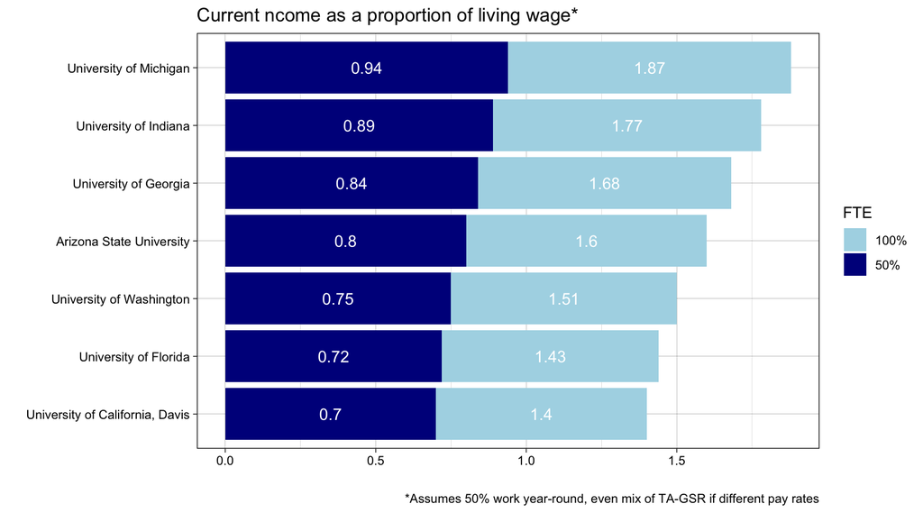

Once adjusting for the cost of living, UCD compares poorly to its peers. The average proportion of the living wage covered by 50% employment (at the minimum rate) by the six other schools in these data is .82, which is a whole 12% higher than Davis’s proportion of .7. If I have time to include other UC’s here, I will, considering that the cost of living in these places is much higher. So, despite being harsh on the Union’s data transparency, it is clear:

**UC lags behind graduate programs across the country and needs to take considerable action to step up.**

## How do Union demands map onto to national grad pay norms?

**The UC’s current proposal** – which has been rejected by the Union – is for a 7% raise increase. This kind of raise would bring the minimum from $28,622 to $30,625.54. It is also important to note that 3% of that is a standard inflation increase and the remaining 4% still does not cover the rate of inflation that we’ve endured in 2022. In the context of living wages, this still leaves UC Davis far below average compared to its peers, with **minimum-pay grad students still earning only .75 of the living wage**.

[figure not shown]

Though as I’ve mentioned, different UC campuses have different costs of living, listed below:

| UC Campus | Living wage |
| --- | --- |
| Berkeley | $ 53,149 |
| Santa Barbara | $ 52,675 |
| Los Angeles | $ 45,536 |
| San Diego | $ 47,304 |
| Riverside | $ 38,821 |
| Merced | $ 34,219 |
| Irvine | $ 51,843 |
| Santa Cruz | $ 54,571 |
| Davis | $ 40,930 |

So of course the relationship to living wage differs. At UC’s highest-cost campus, Santa Cruz, this minimum is right around the living wage. But **based on data from comparable universities, it seems like 90% of a city’s living wage is a competitive ask**. So what does that more realistic ask – 90% of living wage based on the median living wage across UC campuses – look like?

The values from across MIT’s Living Wage Calculator estimates that the median cost of living across the 9 campuses is $47,304, and 90% of that is $42,573. How does this value then map onto our cross-university comparison, for UC Davis? This puts UCD in a very competitive situation at right about 5% above living, but leaves somewhere like Santa Cruz still around the average pay rate relative to living wage, right around 78% of living wage.

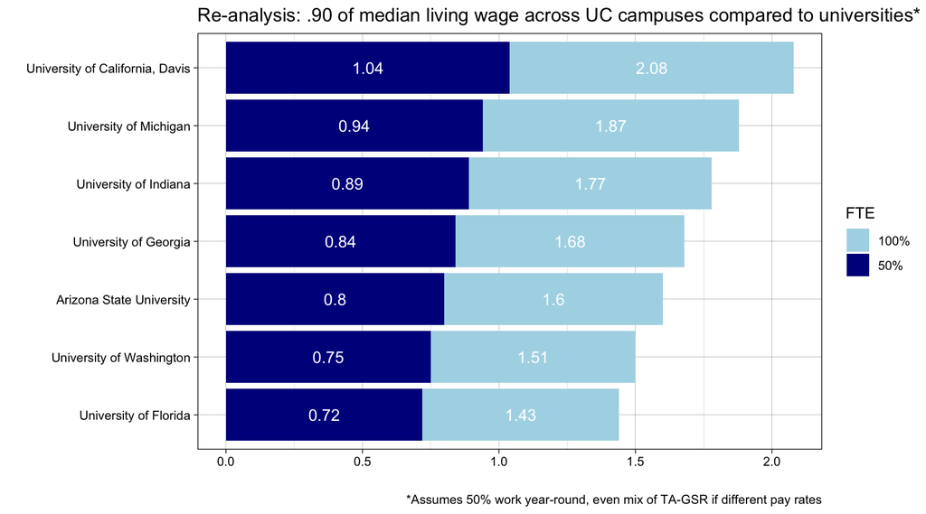

## Re-analysis in the context of barganing

**tl;dr I will strike to increase bargaining power in the hopes that we can agree to a reasonable middle-ground, making the UC a system with competitive university pay. If we agree to a fixed value across the UC, Davis will benefit more than others, and places like Santa Cruz will still be on the tail end of pay to living wage spectrum.**